# act_report

## WeRateDogs Data Analysis and visualization Report

## Introduction:

WeRateDogs is a Twitter account that rates people's dogs with a humorous comment about the dog. This analysis report produced after I wrangling WeRateDogs Data.

[figure not shown]

```python
from IPython.display import HTML

HTML('''<script>
code_show=true;
function code_toggle() {
 if (code_show){
 $('div.input').hide();
 } else {
 $('div.input').show();
 }
 code_show = !code_show
}
$( document ).ready(code_toggle);
</script>
<form action="javascript:code_toggle()"><input type="submit" value="Click here to toggle on/off the raw code."></form>''')
```

```python
# Importing the required libraries
import pandas as pd
import numpy as np
import matplotlib.pyplot as plt
import seaborn as sns
sns.set_style('darkgrid')

% matplotlib inline
```

```python
# @hidden_cell
# read the twitter_archive_master.csv file
we_rate_dog_tweet_df = pd.read_csv('twitter_archive_master.csv')
```

### What is the most used source for the we rate dog tweet?

I found that iPhone Twitter is the most used where 1276 out of 1364 (93.4%)

### What is the most used rating percentage ?

I found that we rate dog tweet ratings is around 100% and this ratings is for fun and humor.

### What is the most dog names in our date frame and it's relation with likes ?

I found that even though stephan is not the most 10 dog names in our data frame, he has the most likes for his video , so the no clear relation between dog name and likes.

This is [stephan video](https://twitter.com/dog_rates/status/807106840509214720/video/1) .

- Top favorite count dog names :
  - Oliver 8
  - Lucy 7
  - Tucker 7
  - Winston 7
  - Cooper 6
  - Lola 6
  - Penny 6
  - Bailey 5
  - Bella 5
  - Sadie 5

### What is the mean retweet_count and favorite_count for dog_stage ?

I found that 11.3% of our tweet has pupper stage and this is the most percentage by huge difference than other stages where doggo 3.07% puppo 1.17% , floofer 0.29% and 0.58% of tweet have multiple dog stage

I found Interesting result where even though the pupper has most percenatge of our tweet (11.3%) , it's the least retweeted and tweet with multiple dog stage has the largest mean of 6275 retweet. Also, tweet with multiple satge has the largest favorite mean of 18848, so it seems that tweet with multiple satge tend to motive user to retweet and click favorite. Even though the puppo has percenatge of 1.17 % out from our tweet , it's the most favorite stage that has mean of 14966 likes compared to doggo, pupper and floofer and the reason might be that one image (funiest) can has huge number of favorite than others

| retweet_count | favorite_count | Dog Stage |
| --- | --- | --- |
| 4447 | 13289.73 | doggo |
| 2145.75 | 5581.50 | floofer |
| 2090 | 6316 | pupper |
| 4523 | 14966 | puppo |
| 6275 | 18848 | multiple |

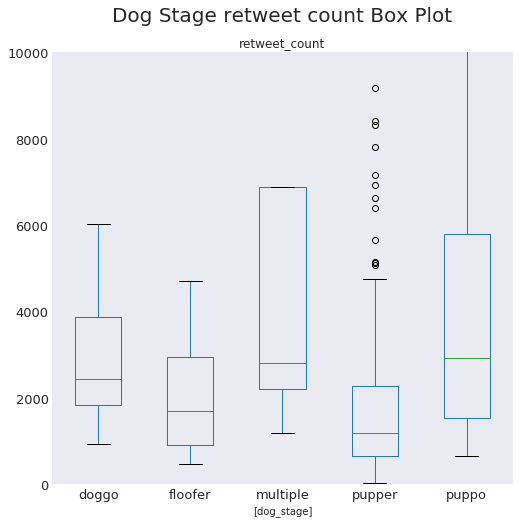

```python
# @hidden_cell
plt.figure()
we_rate_dog_tweet_df[we_rate_dog_tweet_df['dog_stage']!= ''].boxplot(column= ['retweet_count'], by= ['dog_stage'], grid= False, fontsize = 13, figsize = (8,8))
plt.ylim(0,10000)
plt.suptitle('Dog Stage retweet count Box Plot', fontsize=20)

plt.show()
```

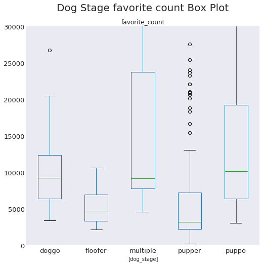

```python
# @hidden_cell
plt.figure()
we_rate_dog_tweet_df[we_rate_dog_tweet_df['dog_stage']!= ''].boxplot(column= ['favorite_count'], by= ['dog_stage'], grid= False, fontsize = 13, figsize = (8,8))
plt.ylim(0,30000)
plt.suptitle('Dog Stage favorite count Box Plot', fontsize=20)

plt.show()
```